# EDA for Financial Data Science

Author

Mike Aguilar

# Housekeeping

```r
cat("\014")  # clear console
```

```r
rm(list = ls())  # clear the workspace
if (!requireNamespace("here", quietly = TRUE)) install.packages("here")
suppressPackageStartupMessages(library(here))
source(here("Supporting", "ProjectSetup.R"))
```

Goal: Summarize the behavior of the simple daily net returns for IBM, FORD, CAT, AAPL, and DIS from the beginning of 2020 through the end of 2025

# Data

## Data Acquisition

Task: Create a parameter list of the tickers and dates

```r
params = list(
  tickers = c("IBM", "F", "CAT", "AAPL", "DIS"),
  startdate = "2019-12-20",
  enddate = "2025-12-31"
)
```

Q: If we want 2020 through 2025, why are we grabbing data from 2019.

A:

- We were tasked with computing returns from the beginning of 2020.
- Best practice is to using daily adjusted closing prices.
- If we used the adjusted closing price on the first day of 2020, we’d miss the market action throughout that first day.
- So, we need the adjusted close for the last trading day of 2019.
- Note that we don’t know that in advance; at least not without looking it up.
- So, we usually grab more data than we need and trim later.

Task: Load the tickers with the getSymbols function

```r
getSymbols(
  params$tickers,
  src = "yahoo",
  from = params$startdate,
  to = params$enddate,
  index.class = "POSIXct"
)
```

```
[1] "IBM"  "F"    "CAT"  "AAPL" "DIS"
```

Task: Create a wide data object containing the adjusted closing prices for all of the assets.

```r
AdjPrices_Wide <- do.call(
  merge,
  lapply(params$tickers, function(x) Ad(get(x)))
)
```

Task: Add the date to that wide object

```r
AdjPrices_Wide <- AdjPrices_Wide %>%
  as_tibble(rownames = "date") %>%
  mutate(date = as.Date(date))
```

Task: Transpose the wide object to long format

```r
AdjPrices_Long <- AdjPrices_Wide %>%
  pivot_longer(-date, names_to = "ticker", values_to = "adj_close")
```

Task: Rename the columns so that they conform to the tickers and does not have the .Adjusted suffix

```r
AdjPrices_Long <- AdjPrices_Long %>%
  mutate(ticker = str_remove(ticker, "\\.Adjusted$"))
```

We will use this long data object throughout the rest of the exercise, unless otherwise stated.

## Cleaning

Task: Peak at the head and tail of the long data

```r
head(AdjPrices_Long)
```

```
# A tibble: 6 × 3
  date       ticker adj_close
  <date>     <chr>      <dbl>
1 2019-12-20 IBM        98.1
2 2019-12-20 F           6.84
3 2019-12-20 CAT       129.
4 2019-12-20 AAPL       67.2
5 2019-12-20 DIS       142.
6 2019-12-23 IBM        98.1
```

```r
tail(AdjPrices_Long)
```

```
# A tibble: 6 × 3
  date       ticker adj_close
  <date>     <chr>      <dbl>
1 2025-12-29 DIS        113.
2 2025-12-30 IBM        296.
3 2025-12-30 F           12.8
4 2025-12-30 CAT        574.
5 2025-12-30 AAPL       272.
6 2025-12-30 DIS        114.
```

Task: Count missing

```r
AdjPrices_Long %>%
  summarise(across(everything(), ~sum(is.na(.))))
```

```
# A tibble: 1 × 3
   date ticker adj_close
  <int>  <int>     <int>
1     0      0         0
```

Task: Count negative prices

```r
AdjPrices_Long %>%
  group_by(ticker) %>%
  summarise(n_negative = sum(adj_close < 0))
```

```
# A tibble: 5 × 2
  ticker n_negative
  <chr>       <int>
1 AAPL            0
2 CAT             0
3 DIS             0
4 F               0
5 IBM             0
```

Q: Any concerns?

A: None identified. The data appears to be clean, with no missing values nor negative prices in the adj_close column.

## Engineering

Task: Generate simple daily net returns

```r
Returns_Long <- AdjPrices_Long %>%
  arrange(ticker, date) %>%
  group_by(ticker) %>%
  mutate(return = adj_close / lag(adj_close) - 1) %>%
  ungroup()
```

Q: Why is the group_by vital?

A:

- Returns must be constructed by asset.
- Without the group_by we could fall into a trap: computing the return along the adj_close column without accounting for variation in ticker. For instance, we don’t want to use the first day of CAT and the last day of AAPL.

Task: Verify the returns avoid this trap by filtering on the last days of AAPL and the first days of CAT.

```r
tickers_sorted <- sort(unique(Returns_Long$ticker))
current <- "AAPL"
next_ticker <- tickers_sorted[which(tickers_sorted == current) + 1]

bind_rows(
  Returns_Long %>% filter(ticker == current) %>% tail(),
  Returns_Long %>% filter(ticker == next_ticker) %>% head()
)
```

```
# A tibble: 12 × 4
   date       ticker adj_close    return
   <date>     <chr>      <dbl>     <dbl>
 1 2025-12-22 AAPL        270. -0.00987
 2 2025-12-23 AAPL        272.  0.00513
 3 2025-12-24 AAPL        273.  0.00532
 4 2025-12-26 AAPL        273. -0.00150
 5 2025-12-29 AAPL        273.  0.00132
 6 2025-12-30 AAPL        272. -0.00248
 7 2019-12-20 CAT         129. NA
 8 2019-12-23 CAT         130.  0.00630
 9 2019-12-24 CAT         129. -0.00687
10 2019-12-26 CAT         130.  0.00502
11 2019-12-27 CAT         130.  0.000405
12 2019-12-30 CAT         129. -0.00513
```

Q: How do we know we didn’t fall into the trap?

A: The first CAT return is NA, because there was no CAT price available prior to that date, eventhough there was a value within the data object prior to that first day.

Task: Trim the returns object so that it only covers the date range of interest.

```r
Returns_Long<-Returns_Long %>%
  filter(date>="2020-01-01")
min(Returns_Long$date)
```

```
[1] "2020-01-02"
```

Task: Clean the missing observations resulting from this engineering. Use na.omit.

```r
Returns_Long <- na.omit(Returns_Long)
```

# Exploration

## Univariate Summary

Task: Run the summary function on the return column from Returns_Long.

```r
summary(Returns_Long$return)
```

```
      Min.    1st Qu.     Median       Mean    3rd Qu.       Max.
-0.1836139 -0.0091181  0.0007144  0.0008108  0.0109121  0.2344137
```

Q: What’s potentially misleading with this approach?

A: It is summarizing over all of the days across all assets. That might be useful, but isn’t expected.

Task: Create a custom dyplr call that generates mean, std dev, skew, kurt, min, q10, q25, q50, q75, q90, max. Apply to each asset.

```r
Returns_Long %>%
  dplyr::select(ticker, return) %>%
  group_by(ticker) %>%
  summarise(across(where(is.numeric),
  .fns = list(
    min = ~round(min(., na.rm = TRUE), 2),
    median = ~round(median(., na.rm = TRUE), 2),
    mean = ~round(mean(., na.rm = TRUE), 3),
    stdev = ~round(sd(., na.rm = TRUE), 3),
    skew = ~round(skewness(.,na.rm=TRUE),2),
    kurt = ~round(kurtosis(.,na.rm=TRUE),2), # Not excess
    q10 = ~round(quantile(., 0.10, na.rm = TRUE), 2),
    q25 = ~round(quantile(., 0.25, na.rm = TRUE), 2),
    q75 = ~round(quantile(., 0.75, na.rm = TRUE), 2),
    q90 = ~round(quantile(., 0.90, na.rm = TRUE), 2),
    max = ~round(max(., na.rm = TRUE), 2)
  ),
  .names = "{fn}"
  ))
```

```
# A tibble: 5 × 12
  ticker   min median  mean stdev  skew  kurt   q10   q25   q75   q90   max
  <chr>  <dbl>  <dbl> <dbl> <dbl> <dbl> <dbl> <dbl> <dbl> <dbl> <dbl> <dbl>
1 AAPL   -0.13      0 0.001 0.02   0.28  9.75 -0.02 -0.01  0.01  0.02  0.15
2 CAT    -0.14      0 0.001 0.02  -0.01  7.83 -0.02 -0.01  0.01  0.02  0.12
3 DIS    -0.13      0 0     0.021  0.35 11.9  -0.02 -0.01  0.01  0.02  0.14
4 F      -0.18      0 0.001 0.027  0.18 10.2  -0.03 -0.01  0.01  0.03  0.23
5 IBM    -0.13      0 0.001 0.017 -0.14 13.2  -0.02 -0.01  0.01  0.02  0.13
```

Q: Does the data follow a normal distribution?

A:

- There is slight skewness (both positive and negative) across the assets, which might suggest normality.
- But there is excess kurtosis in all of the assets, which strongly suggests non-normality.

Task: Focus on the first asset from the ticker list within your parameter settings. Generate a frequency histogram of returns.

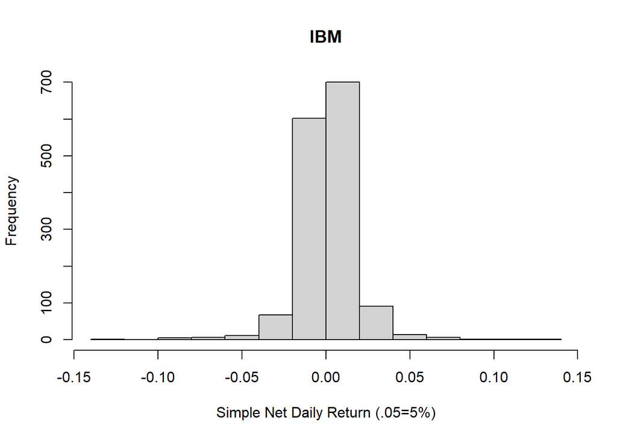

```r
first_ticker<-params$tickers[1]
temp<-Returns_Long %>%
  filter(ticker == first_ticker) %>%
  select(return)
hist(
  temp$return,
  main = first_ticker,
  xlab = "Simple Net Daily Return (.05=5%)"
)
```

Task: Using that same asset, generate a relative frequency histogram with an overlay of a Normal distribution. Also add a subtitle indicating the start and end dates for returns.

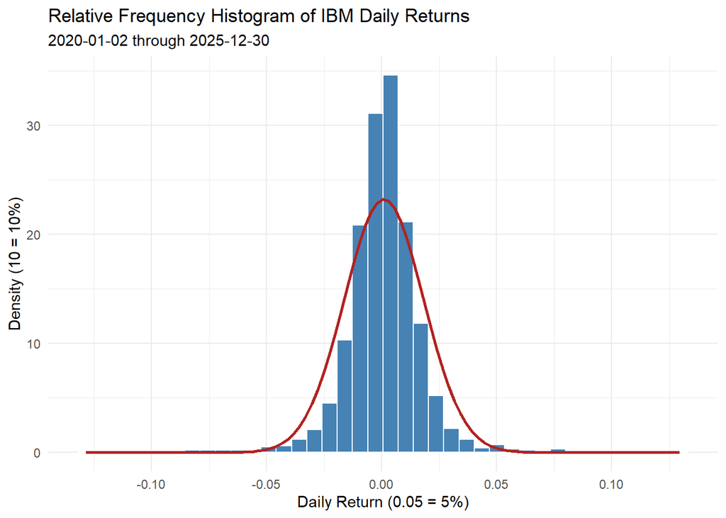

```r
mu <- mean(temp$return)
sigma <- sd(temp$return)
first_day <- Returns_Long$date[1]
last_day <- Returns_Long$date[nrow(Returns_Long)]
subtitle_text <- paste0(first_day," through ",last_day)

ggplot(temp, aes(x = return)) +
  geom_histogram(aes(y = after_stat(density)), bins = 40, fill = "steelblue", color = "white") +
  stat_function(fun = dnorm, args = list(mean = mu, sd = sigma), color = "firebrick", linewidth = 1) +
  labs(
    title = paste("Relative Frequency Histogram of", first_ticker, "Daily Returns"),
    subtitle = subtitle_text,
    x = "Daily Return (0.05 = 5%)",
    y = "Density (10 = 10%)"
  ) +
  theme_minimal()
```

Q: Does the data follow a normal distribution?

A: The peakedness of the distribution near the center is suggestive of a heavy-tailed distribution.

Task: Using that same asset, generate a QQ Plot

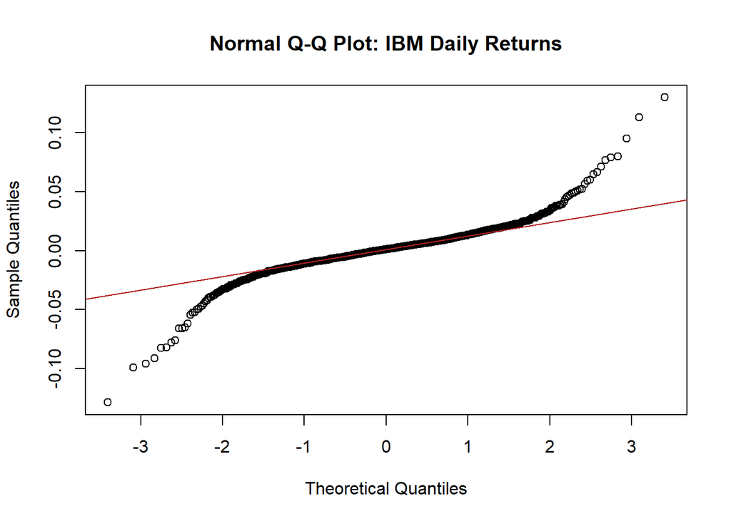

```r
qqnorm(temp$return, main = paste("Normal Q-Q Plot:", first_ticker, "Daily Returns"))
qqline(temp$return, col = "firebrick")
```

Q: Interpret the QQ Plot

A:

- The QQ plot compares the distribution of the asset’s daily returns to a normal distribution. If the points closely follow the straight line, it suggests that the returns are approximately normally distributed. Deviations from the line indicate skewness or heavy tails in the distribution.
- Focus on the left tail. The sample quantiles are lower (more negative) than they are for the normal distribution, indicating non normality.
- We see something simmilar in the right tail.
- Financial returns are often approximately normal in the center of the distribution but exhibit much heavier tails than a normal distribution, implying that extreme market movements occur more frequently than a normal model would suggest.

Task: Generate a single figure with violin plots of the densities for each asset side by side.

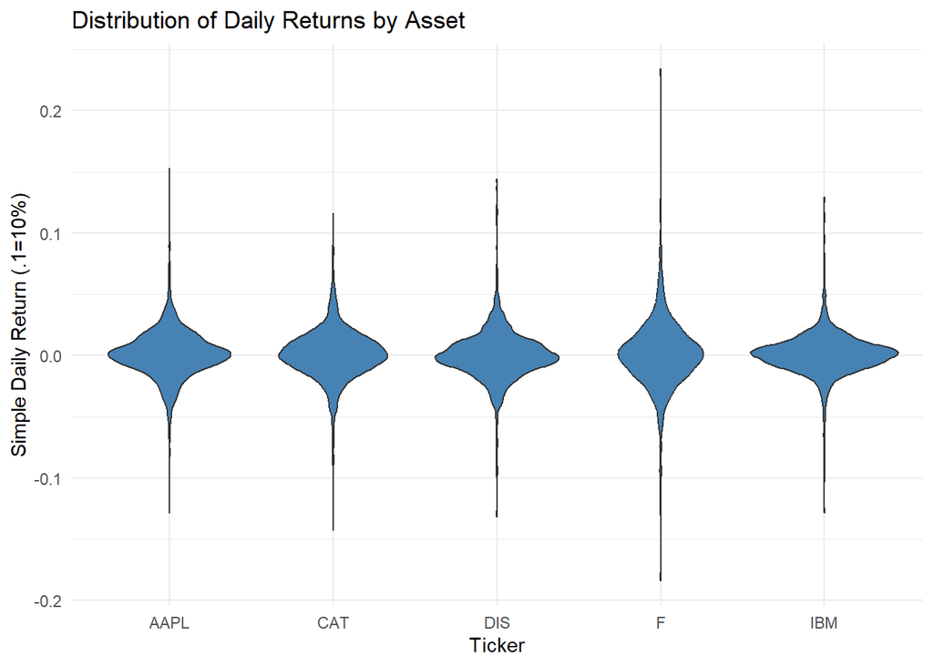

```r
ggplot(Returns_Long, aes(x = ticker, y = return)) +
  geom_violin(fill = "steelblue") +
  labs(
    title = "Distribution of Daily Returns by Asset",
    x = "Ticker",
    y = "Simple Daily Return (.1=10%)"
  ) +
  theme_minimal()
```

Q: Which asset looks most extreme in this violin plot?

A: F appears to have the widest spread and longest tails of the five. But before concluding that F’s *return distribution* is the most extreme (in a distributional-shape sense), we need to account for the fact that F simply has higher volatility. Comparing raw returns conflates scale (volatility) with shape (skew/kurtosis).

Task: Build a table of the raw return quantiles (q10, q25, q50, q75, q90) for each ticker, with a Normal(0,1) reference row for comparison.

```r
probs <- c(0.01, 0.10, 0.25, 0.50, 0.75, 0.90, 0.99)
q_names <- paste0("q", probs * 100)

raw_quantiles <- Returns_Long %>%
  group_by(ticker) %>%
  reframe(as_tibble_row(setNames(quantile(return, probs), q_names)))

normal_quantiles_raw <- as_tibble_row(setNames(qnorm(probs), q_names)) %>%
  mutate(ticker = "Normal", .before = 1)

bind_rows(normal_quantiles_raw, raw_quantiles)
```

```
# A tibble: 6 × 8
  ticker      q1     q10      q25       q50     q75    q90    q99
  <chr>    <dbl>   <dbl>    <dbl>     <dbl>   <dbl>  <dbl>  <dbl>
1 Normal -2.33   -1.28   -0.674    0        0.674   1.28   2.33
2 AAPL   -0.0498 -0.0209 -0.00821  0.00114  0.0115  0.0220 0.0526
3 CAT    -0.0544 -0.0208 -0.00939  0.00111  0.0119  0.0226 0.0557
4 DIS    -0.0554 -0.0209 -0.00943 -0.000292 0.00973 0.0218 0.0605
5 F      -0.0760 -0.0280 -0.0135   0.000601 0.0141  0.0287 0.0746
6 IBM    -0.0500 -0.0152 -0.00689  0.00104  0.00855 0.0178 0.0499
```

Q: Does this raw-scale table support the “F is most extreme” impression from the violin plot?

A: Yes; F’s raw quantiles are the widest of the five tickers, consistent with the violin plot. But notice the Normal(0,1) row is on an entirely different scale than any of the raw return columns (unit variance vs. returns on the order of a few percent), so this comparison mixes scale with shape and isn’t yet telling us about *distributional shape* relative to Normal.

Task: Standardize each asset relative to its own history (z-score), then regenerate the violin plot on the standardized scale.

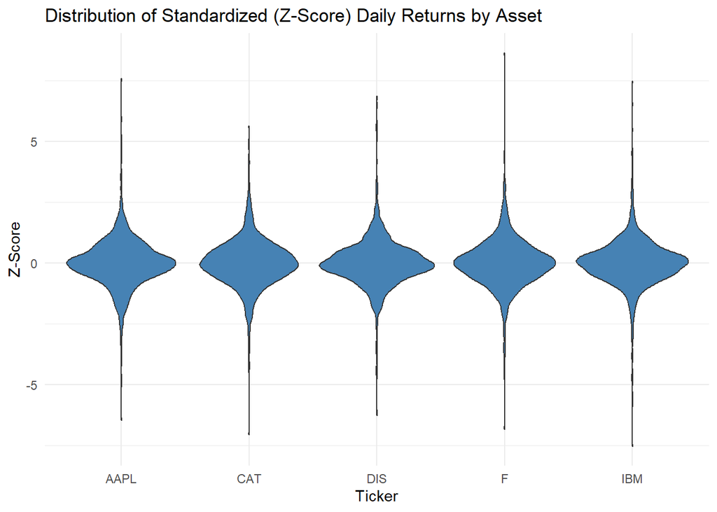

```r
Returns_Long_z <- Returns_Long %>%
  group_by(ticker) %>%
  mutate(z = (return - mean(return)) / sd(return)) %>%
  ungroup()

ggplot(Returns_Long_z, aes(x = ticker, y = z)) +
  geom_violin(fill = "steelblue") +
  labs(
    title = "Distribution of Standardized (Z-Score) Daily Returns by Asset",
    x = "Ticker",
    y = "Z-Score"
  ) +
  theme_minimal()
```

Task: Compute the q1, q10, q25, q50, q75, q90, q99 of each asset’s z score. Display in a table where these quantiles are the columns, and the rows pertain to the Normal distribution followed by each ticker.

```r
ticker_quantiles <- Returns_Long_z %>%
  group_by(ticker) %>%
  reframe(as_tibble_row(setNames(quantile(z, probs), q_names)))

normal_quantiles <- as_tibble_row(setNames(qnorm(probs), q_names)) %>%
  mutate(ticker = "Normal", .before = 1)

bind_rows(normal_quantiles, ticker_quantiles)
```

```
# A tibble: 6 × 8
  ticker    q1    q10    q25      q50   q75   q90   q99
  <chr>  <dbl>  <dbl>  <dbl>    <dbl> <dbl> <dbl> <dbl>
1 Normal -2.33 -1.28  -0.674  0       0.674 1.28   2.33
2 AAPL   -2.54 -1.10  -0.464  0.00221 0.518 1.04   2.57
3 CAT    -2.72 -1.08  -0.518 -0.00439 0.526 1.05   2.67
4 DIS    -2.65 -1.000 -0.453 -0.0178  0.460 1.03   2.88
5 F      -2.85 -1.07  -0.530 -0.00709 0.493 1.03   2.74
6 IBM    -2.96 -0.939 -0.453  0.00911 0.446 0.984  2.85
```

Q: Now that we’ve standardized, is F still the most extreme?

A:

- Once volatility is removed via standardization, the ranking changes: F’s *shape* relative to Normal is no longer clearly the most extreme, and other tickers’ relative tail behavior becomes more comparable.
- A wide violin plot on the raw scale can just mean “high volatility,” not “heavier tails.” Standardizing isolates shape (skewness, kurtosis) from scale (volatility), which is what we actually care about when asking whether a distribution is close to Normal.

## Evolution over time

Task: Focus on the first ticker again. Plot the adjusted closing price using the basic “plot” function.

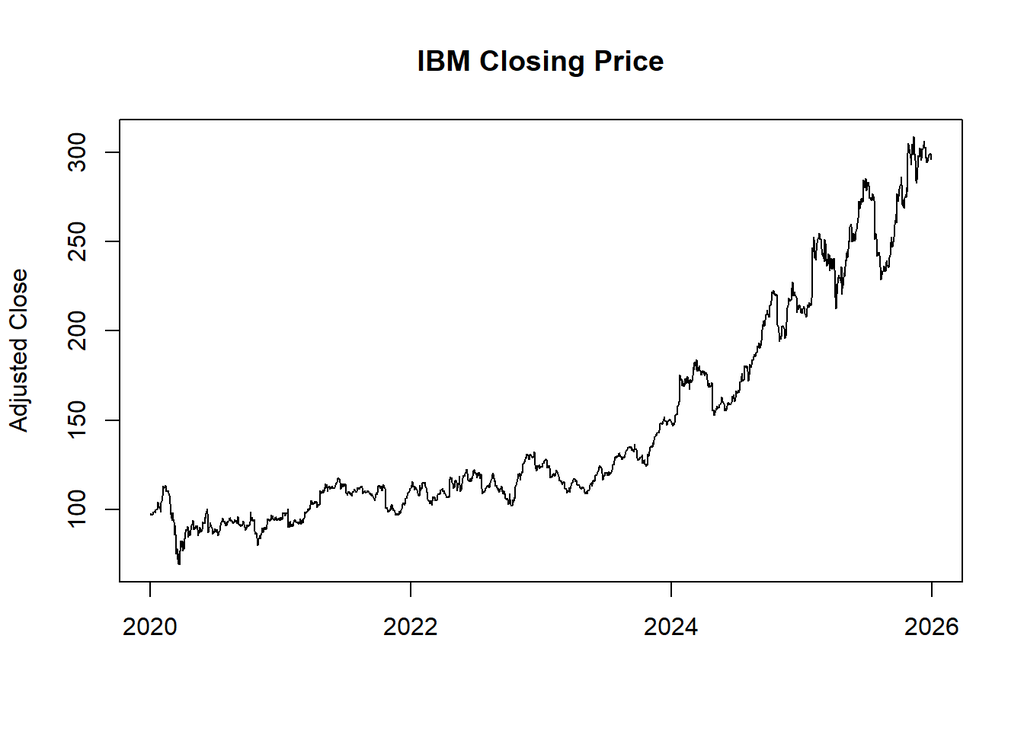

```r
temp <- Returns_Long %>%
  filter(ticker == first_ticker) %>%
  select(date, adj_close)

plot(temp$date, temp$adj_close, type = "l",
     xlab = "", ylab = "Adjusted Close",
     main = paste(first_ticker, "Closing Price"))
```

Task: Using that same asset, plot the closing price for the last 6mths as a candlestick using the chart_Series function.

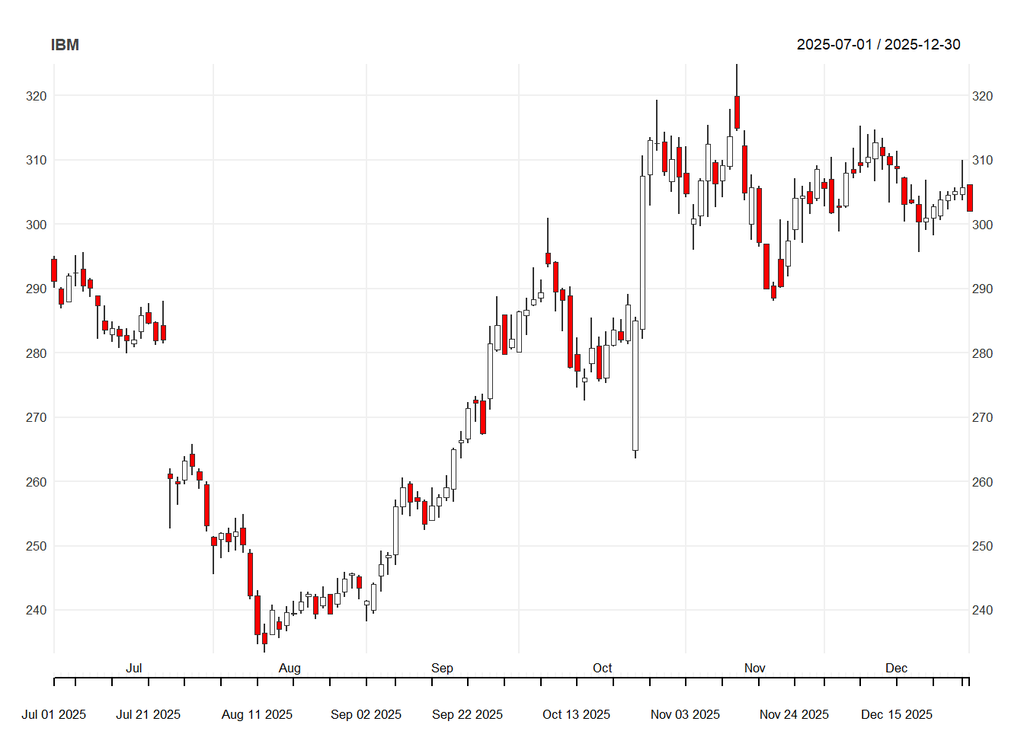

```r
chart_Series(x = last(get(first_ticker), "6 months"),
             type = "candlesticks", name = first_ticker)
```

Task: Using that same asset, create a drawdown chart using charts.PerformanceSummary.

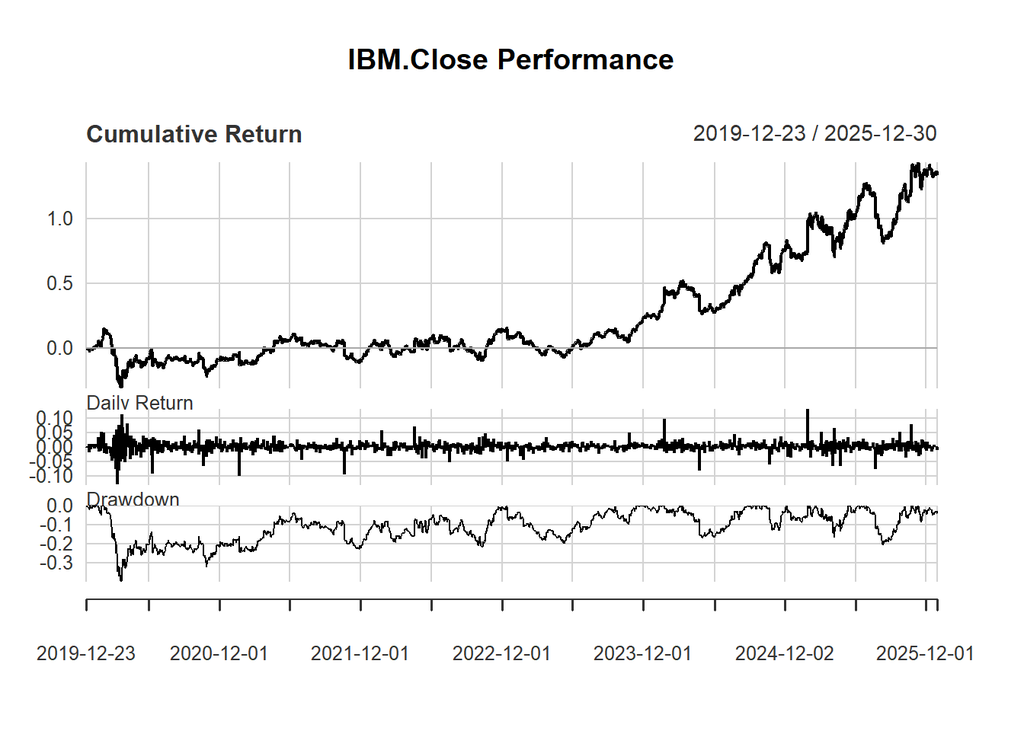

```r
charts.PerformanceSummary(na.omit(Return.calculate(Cl(get(first_ticker)), method = "discrete")))
```

Task: Using that same asset, compute 20 day rolling mean returns. Also compute 250 day rolling mean returns. Create a plot overlaying these series.

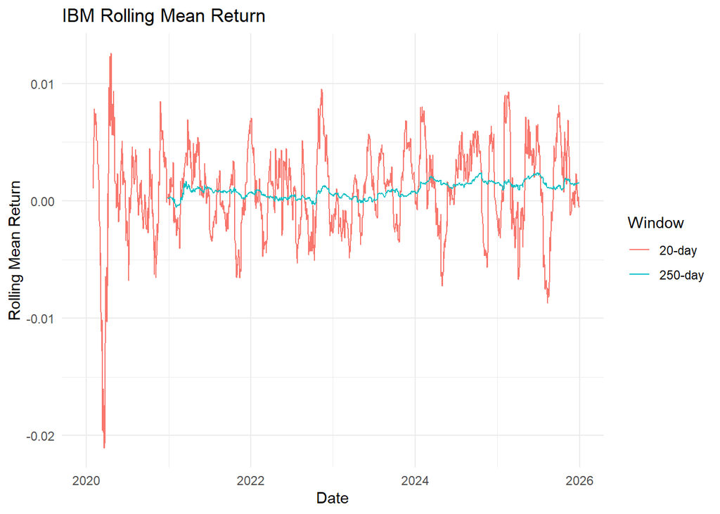

```r
roll_df <- Returns_Long %>%
  filter(ticker == first_ticker) %>%
  arrange(date) %>%
  mutate(
    roll_20  = zoo::rollmean(return, k = 20, fill = NA, align = "right"),
    roll_250 = zoo::rollmean(return, k = 250, fill = NA, align = "right")
  )

ggplot(roll_df, aes(x = date)) +
  geom_line(aes(y = roll_20, color = "20-day")) +
  geom_line(aes(y = roll_250, color = "250-day")) +
  labs(
    title = paste(first_ticker, "Rolling Mean Return"),
    x = "Date", y = "Rolling Mean Return", color = "Window"
  ) +
  theme_minimal()
```

Task: Using that same asset, compute 20 day rolling mean of returns SQUARED. Also compute 250 day rolling mean returns. Create a plot overlaying these series.

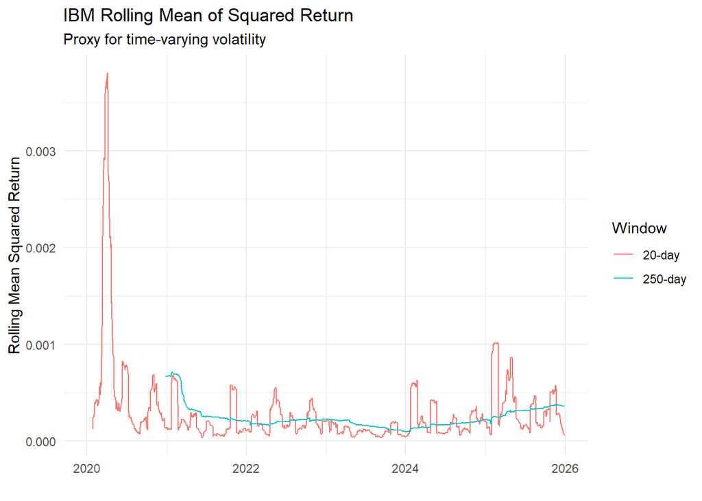

```r
roll_sq_df <- Returns_Long %>%
  filter(ticker == first_ticker) %>%
  arrange(date) %>%
  mutate(
    roll_sq_20  = zoo::rollmean(return^2, k = 20, fill = NA, align = "right"),
    roll_sq_250 = zoo::rollmean(return^2, k = 250, fill = NA, align = "right")
  )

ggplot(roll_sq_df, aes(x = date)) +
  geom_line(aes(y = roll_sq_20, color = "20-day")) +
  geom_line(aes(y = roll_sq_250, color = "250-day")) +
  labs(
    title = paste(first_ticker, "Rolling Mean of Squared Return"),
    subtitle = "Proxy for time-varying volatility",
    x = "", y = "Rolling Mean Squared Return", color = "Window"
  ) +
  theme_minimal()
```

Task: Using that same asset, compute 20 day rolling standard deviation of returns. Also compute 250 day rolling mean returns. Create a plot overlaying these series.

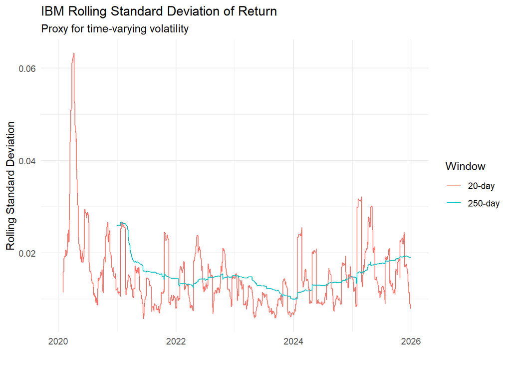

```r
roll_sd_df <- Returns_Long %>%
  filter(ticker == first_ticker) %>%
  arrange(date) %>%
  mutate(
    roll_sd_20  = zoo::rollapply(return, width = 20, FUN = sd, fill = NA, align = "right"),
    roll_sd_250 = zoo::rollapply(return, width = 250, FUN = sd, fill = NA, align = "right")
  )

ggplot(roll_sd_df, aes(x = date)) +
  geom_line(aes(y = roll_sd_20, color = "20-day")) +
  geom_line(aes(y = roll_sd_250, color = "250-day")) +
  labs(
    title = paste(first_ticker, "Rolling Standard Deviation of Return"),
    subtitle = "Proxy for time-varying volatility",
    x = "", y = "Rolling Standard Deviation", color = "Window"
  ) +
  theme_minimal()
```

Task: Using that same asset, compute 20 day rolling skewness returns. Also compute 250 day rolling mean returns. Create a plot overlaying these series.

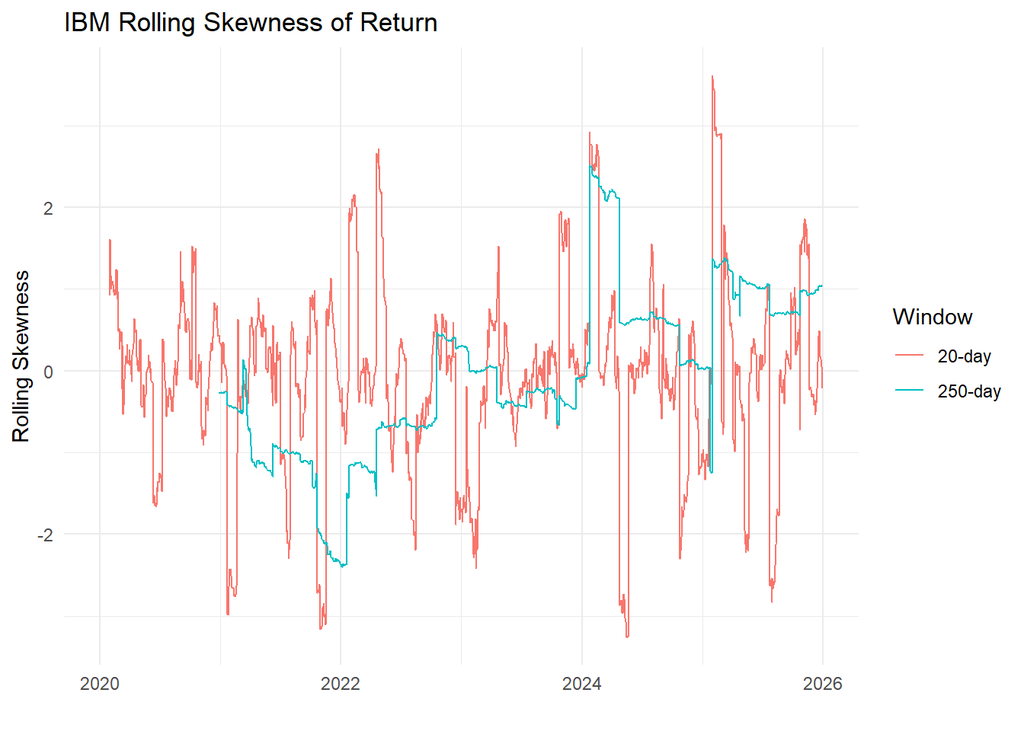

```r
roll_skew_df <- Returns_Long %>%
  filter(ticker == first_ticker) %>%
  arrange(date) %>%
  mutate(
    roll_skew_20  = zoo::rollapply(return, width = 20, FUN = skewness, fill = NA, align = "right"),
    roll_skew_250 = zoo::rollapply(return, width = 250, FUN = skewness, fill = NA, align = "right")
  )

ggplot(roll_skew_df, aes(x = date)) +
  geom_line(aes(y = roll_skew_20, color = "20-day")) +
  geom_line(aes(y = roll_skew_250, color = "250-day")) +
  labs(
    title = paste(first_ticker, "Rolling Skewness of Return"),
    x = "", y = "Rolling Skewness", color = "Window"
  ) +
  theme_minimal()
```

Task: Using that same asset, compute 20 day rolling kurtosis returns. Also compute 250 day rolling mean returns. Create a plot overlaying these series.

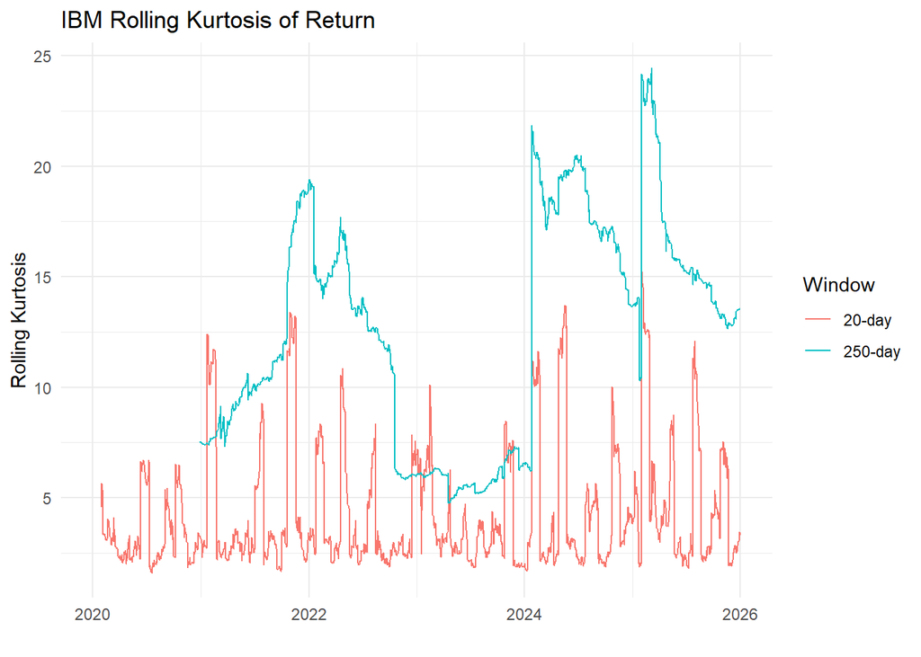

```r
roll_kurt_df <- Returns_Long %>%
  filter(ticker == first_ticker) %>%
  arrange(date) %>%
  mutate(
    roll_kurt_20  = zoo::rollapply(return, width = 20, FUN = kurtosis, fill = NA, align = "right"),
    roll_kurt_250 = zoo::rollapply(return, width = 250, FUN = kurtosis, fill = NA, align = "right")
  )

ggplot(roll_kurt_df, aes(x = date)) +
  geom_line(aes(y = roll_kurt_20, color = "20-day")) +
  geom_line(aes(y = roll_kurt_250, color = "250-day")) +
  labs(
    title = paste(first_ticker, "Rolling Kurtosis of Return"),
    x = "", y = "Rolling Kurtosis", color = "Window"
  ) +
  theme_minimal()
```

Task: Create a plot that indexes the adjusted closing price to $100 for each asset at the beginning of the sample and then tracks the evolution of that $100 over time.

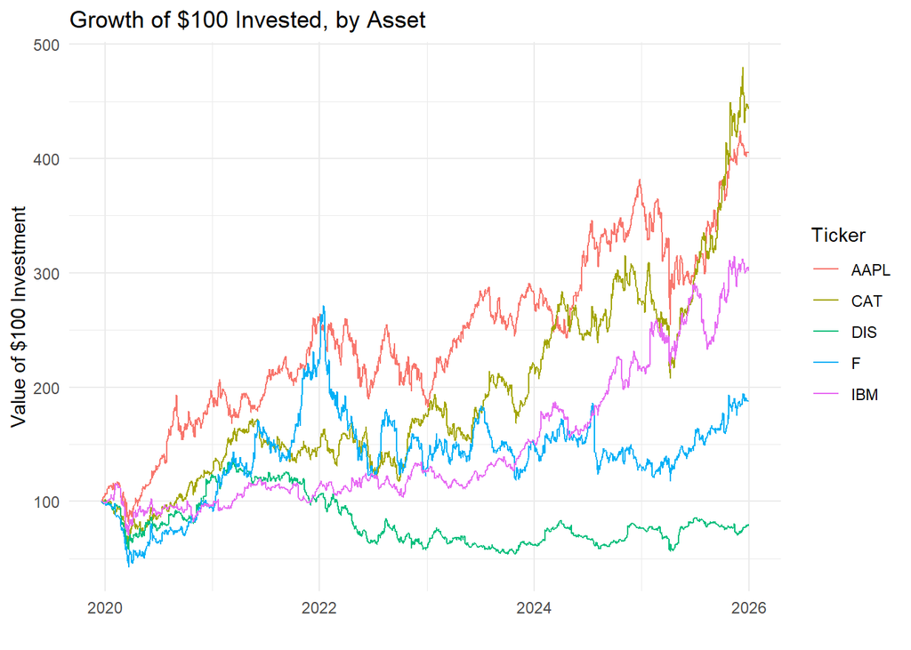

```r
indexed_df <- AdjPrices_Long %>%
  arrange(ticker, date) %>%
  group_by(ticker) %>%
  mutate(indexed_price = 100 * adj_close / first(adj_close)) %>%
  ungroup()

ggplot(indexed_df, aes(x = date, y = indexed_price, color = ticker)) +
  geom_line() +
  labs(
    title = "Growth of $100 Invested, by Asset",
    x = "", y = "Value of $100 Investment", color = "Ticker"
  ) +
  theme_minimal()
```

## Comovement

Task: Pivot returns to wide format for matrix-based comovement analysis.

```r
Returns_Wide <- Returns_Long %>%
  select(date, ticker, return) %>%
  pivot_wider(names_from = ticker, values_from = return) %>%
  arrange(date)
```

Task: Compute the covariance matrix of returns

```r
cov_matrix <- Returns_Wide %>%
  select(-date) %>%
  cov()
round(cov_matrix, 6)
```

```
         AAPL      CAT      DIS        F      IBM
AAPL 0.000402 0.000151 0.000189 0.000203 0.000134
CAT  0.000151 0.000417 0.000209 0.000286 0.000165
DIS  0.000189 0.000209 0.000440 0.000271 0.000146
F    0.000203 0.000286 0.000271 0.000728 0.000178
IBM  0.000134 0.000165 0.000146 0.000178 0.000295
```

Task: Compute the correlation matrix of returns

```r
cor_matrix <- Returns_Wide %>%
  select(-date) %>%
  cor()
round(cor_matrix, 3)
```

```
      AAPL   CAT   DIS     F   IBM
AAPL 1.000 0.369 0.450 0.375 0.388
CAT  0.369 1.000 0.487 0.520 0.469
DIS  0.450 0.487 1.000 0.478 0.404
F    0.375 0.520 0.478 1.000 0.384
IBM  0.388 0.469 0.404 0.384 1.000
```

Task: Visualize the comovement with pairs

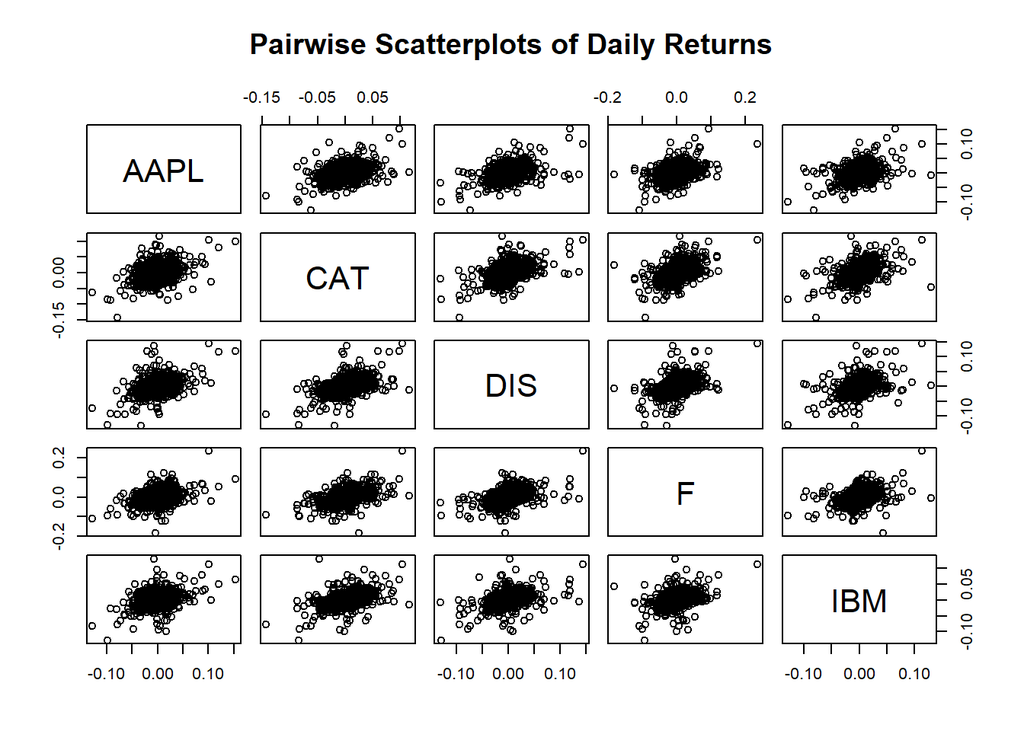

```r
Returns_Wide %>%
  select(-date) %>%
  pairs(main = "Pairwise Scatterplots of Daily Returns")
```

Task: Visualization the correlation with chart.Correlation

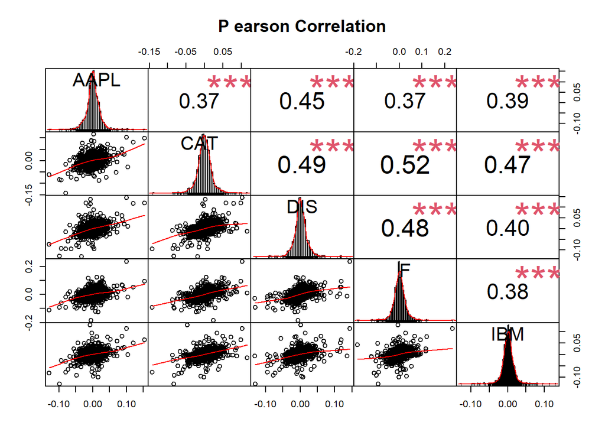

```r
Returns_Wide %>%
  select(-date) %>%
  chart.Correlation(histogram = TRUE)
```

Q: What do the red stars indicate? Interpret within our case.

A:

- The red stars are levels of significance for a hypothesis test H0: correlation = 0 vs H0: correlation not equal 0.
- One star implies significance at the 10% level. 2 stars: 5%; 3 stars 1%
- In our case, all of the correlations are statistically significant at the 1% level.

Task: Compute 250 day rolling correlation between the first and second tickers in the ticker list. Plot this relationship.

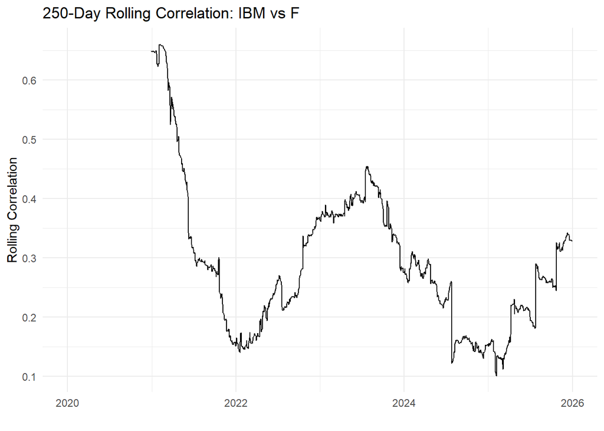

```r
second_ticker <- params$tickers[2]

roll_cor_df <- Returns_Wide %>%
  arrange(date) %>%
  mutate(
    roll_cor_250 = zoo::rollapply(
      cbind(.data[[first_ticker]], .data[[second_ticker]]),
      width = 250,
      FUN = function(x) cor(x[, 1], x[, 2]),
      by.column = FALSE,
      fill = NA,
      align = "right"
    )
  )

ggplot(roll_cor_df, aes(x = date, y = roll_cor_250)) +
  geom_line() +
  labs(
    title = paste("250-Day Rolling Correlation:", first_ticker, "vs", second_ticker),
    x = "", y = "Rolling Correlation"
  ) +
  theme_minimal()
```

Q: How stable is this correlation over time?

A: The 250-day rolling correlation between the two assets fluctuates substantially over the sample, ranging from around 0.1 to over 0.6. Correlations between individual stocks are not static — they shift with the market regime (e.g., macro-driven, high-correlation periods vs. idiosyncratic, low-correlation periods), which has implications for diversification and portfolio risk that a single full-sample correlation number would mask.

## Temporal Dependence

Task: Compute the ACF for each asset’s returns. Let’s use ggACF applied to Returns_Wide wrapped in a function.

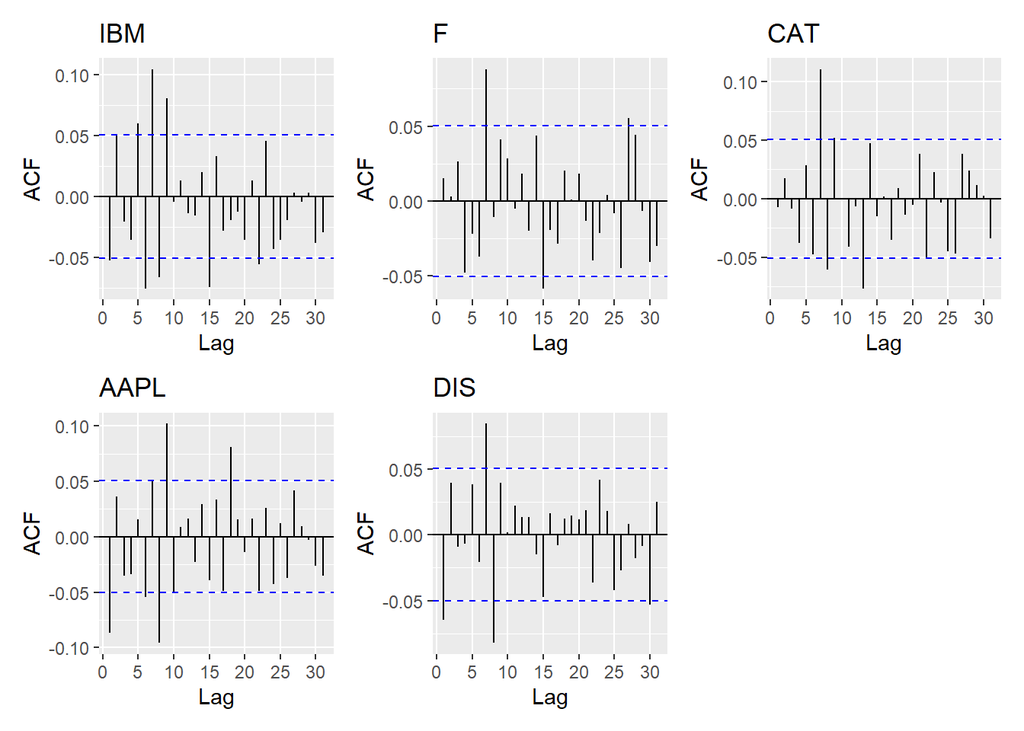

```r
acf_plots <- purrr::map(params$tickers, function(tk) {
  forecast::ggAcf(Returns_Wide[[tk]]) +
    ggplot2::labs(title = tk)
})

patchwork::wrap_plots(acf_plots, ncol = 3)
```

Q: Is there significant autocorrelation in daily returns?

A: For the most part, autocorrelations sit within (or very close to) the significance bands across all five assets, with only a few isolated lags poking through. This is broadly consistent with market efficiency: daily returns show little exploitable linear predictability from their own past.

Task: Pick the first ticker. Compute 5 lags of that asset’s returns.

```r
lag_df <- Returns_Wide %>%
  arrange(date) %>%
  transmute(
    date,
    lag0 = .data[[first_ticker]],
    lag1 = lag(.data[[first_ticker]], 1),
    lag2 = lag(.data[[first_ticker]], 2),
    lag3 = lag(.data[[first_ticker]], 3),
    lag4 = lag(.data[[first_ticker]], 4),
    lag5 = lag(.data[[first_ticker]], 5)
  ) %>%
  na.omit()
```

Task: Visualize the correlation among those lags using ggpairs

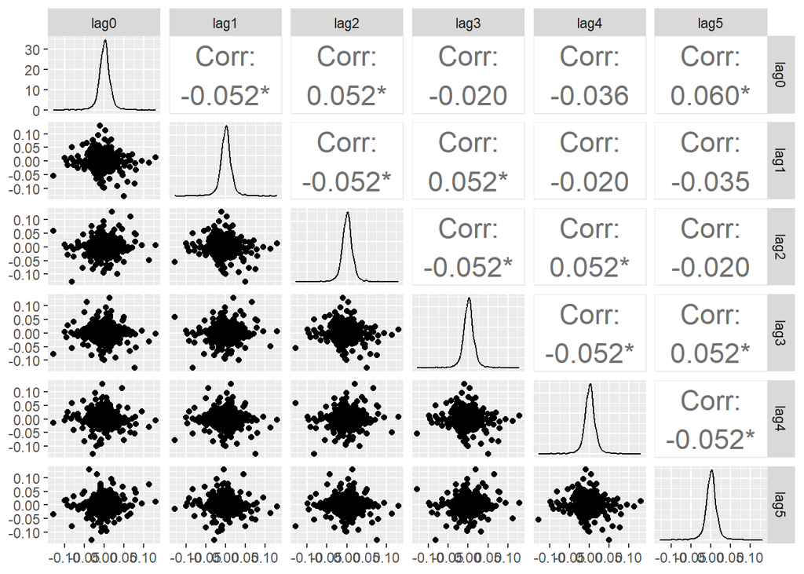

```r
ggpairs(
  lag_df %>% select(-date),
  upper = list(continuous = wrap("cor", size = 6)),
  diag  = list(continuous = wrap("densityDiag")),
  lower = list(continuous = wrap("points"))
)
```

Q: Interpret?

Task: Compute the ACF for each asset’s squared returns. We can do this several ways. In this exercise let’s use ggAcf wrapped in a function.

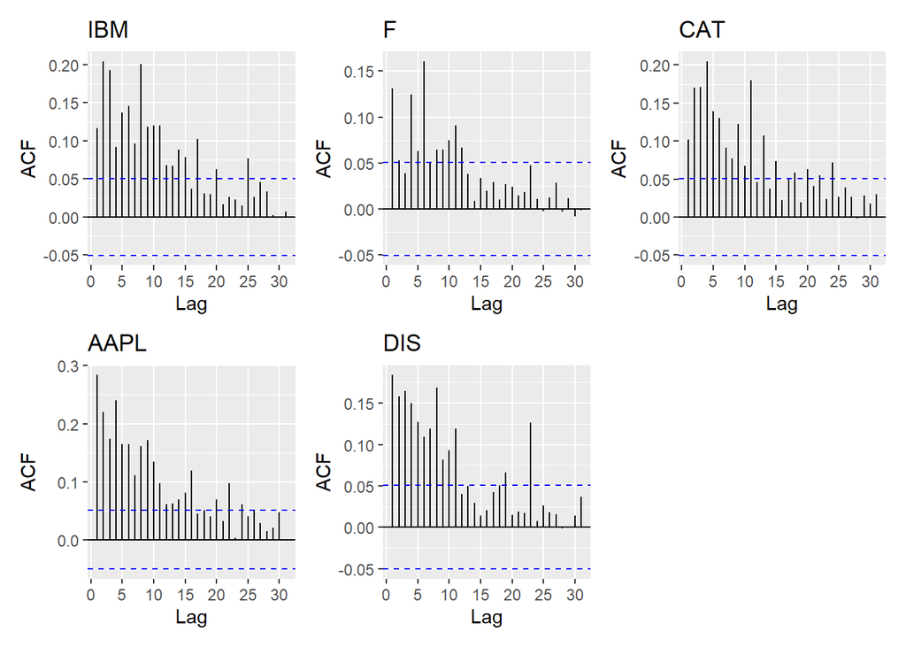

```r
sq_acf_plots <- purrr::map(params$tickers, function(tk) {
  ggAcf(Returns_Wide[[tk]]^2) + labs(title = tk)
})

wrap_plots(sq_acf_plots, ncol = 3)
```

Q: How does this compare to the ACF of raw returns?

A: The squared-return ACFs show strong, persistent positive autocorrelation across many lags for every asset, in sharp contrast to the raw-return ACFs. This is a classic signature of volatility clustering: returns themselves are hard to predict from their own past, but the *magnitude* of returns (and therefore risk) is highly predictable in the short run — a large move today makes a large move tomorrow more likely, regardless of direction. This is exactly what motivates GARCH-type models.

Task: Use the same asset as above. Compute 5 lags of that asset’s squared returns.

```r
sq_lag_df <- Returns_Wide %>%
  arrange(date) %>%
  transmute(
    date,
    lag0 = .data[[first_ticker]]^2,
    lag1 = lag(.data[[first_ticker]]^2, 1),
    lag2 = lag(.data[[first_ticker]]^2, 2),
    lag3 = lag(.data[[first_ticker]]^2, 3),
    lag4 = lag(.data[[first_ticker]]^2, 4),
    lag5 = lag(.data[[first_ticker]]^2, 5)
  ) %>%
  na.omit()
```

Task: Visualize the correlation among those lags. Use ggpairs.

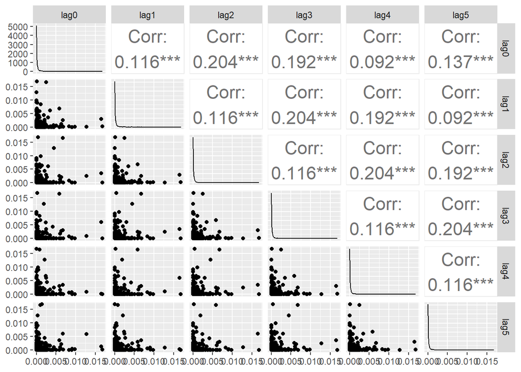

```r
ggpairs(
  sq_lag_df %>% select(-date),
  upper = list(continuous = wrap("cor", size = 6)),
  diag  = list(continuous = wrap("densityDiag")),
  lower = list(continuous = wrap("points"))
)
```

Q: What is the implication of these results?

A:

- Although returns don’t seem to have much persistence, squared returns do seem to depend on their own past.
- The implication is that we can model volatility with a model that exploits temporal persistence.

Task: Pick the first and second tickers Compute the CCF.

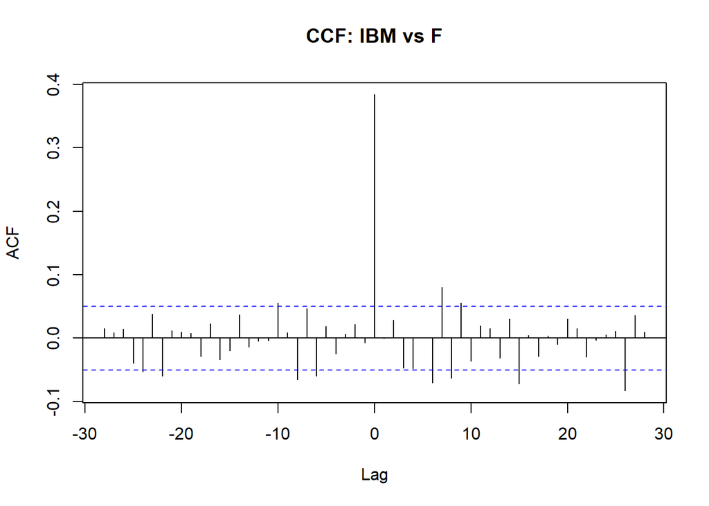

```r
ccf(Returns_Wide[[first_ticker]], Returns_Wide[[second_ticker]],
    main = paste("CCF:", first_ticker, "vs", second_ticker))
```

Q: What does the CCF show?

A: The cross-correlation is clearly dominated by the contemporaneous (lag 0) relationship, reflecting the two stocks’ common exposure to market-wide news arriving on the same day. There is little evidence of a lead-lag relationship at any positive or negative lag.

Task: Lag the second asset 1,2,3,4,5 periods. Visualize the correlations between the first asset and the second asset’s returns and it’s lags.

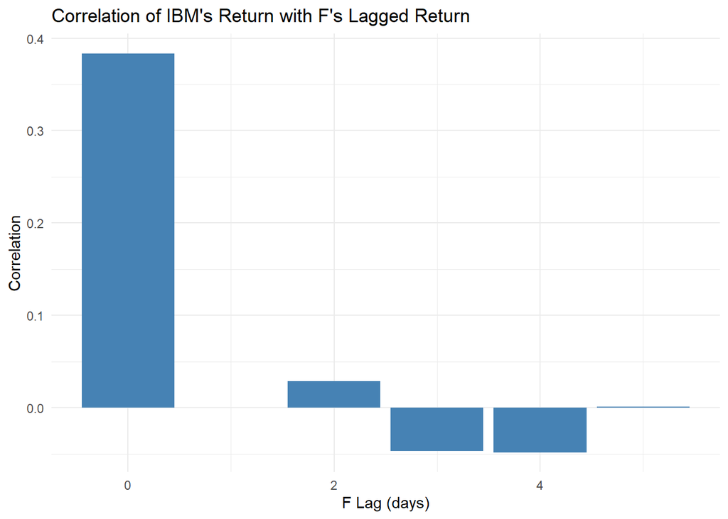

```r
ccf_lag_df <- Returns_Wide %>%
  arrange(date) %>%
  transmute(
    date,
    asset1 = .data[[first_ticker]],
    lag0 = .data[[second_ticker]],
    lag1 = lag(.data[[second_ticker]], 1),
    lag2 = lag(.data[[second_ticker]], 2),
    lag3 = lag(.data[[second_ticker]], 3),
    lag4 = lag(.data[[second_ticker]], 4),
    lag5 = lag(.data[[second_ticker]], 5)
  ) %>%
  na.omit()

cor_vec <- sapply(ccf_lag_df %>% select(starts_with("lag")),
                   function(x) cor(ccf_lag_df$asset1, x))

cor_df <- tibble(lag = 0:5, correlation = cor_vec)

ggplot(cor_df, aes(x = lag, y = correlation)) +
  geom_col(fill = "steelblue") +
  labs(
    title = paste0("Correlation of ", first_ticker, "'s Return with ", second_ticker, "'s Lagged Return"),
    x = paste(second_ticker, "Lag (days)"), y = "Correlation"
  ) +
  theme_minimal()
```

Q: Does lagging the second asset’s return reveal any predictive relationship?

A: No. The correlation is concentrated almost entirely at lag 0 (contemporaneous), and drops to near zero for every positive lag. This reinforces the CCF finding: there’s no meaningful evidence that F’s past returns help predict IBM’s returns beyond what’s already captured by their same-day co-movement.